# compile-regional-data

### 2.2.9 Fraser

#### Chinook

Escapement and run size for Fraser Chinook were provided to PSF by Lauren Weir, DFO (pers. comm.). We took the sum of escapement and terminal run for five major stocks (Fraser Spring 4-2 (age 1.2), Fraser Spring 5-2 (age 1.3), Fraser Summer 5-2 (age 1.3), Fraser Summer 4-1 (age 0.3), and Harrison (Fraser Fall 4-1, age 0.3)). Escapement numbers match those in Table B6 of the [PSC’s Chinook Technical Committee (CTC) data sets](https://www.psc.org/publications/technical-reports/technical-committee-reports/chinook/ctc-data-sets/) as shown by purple open circles below. The ‘t.run’ in the CTC dataset excludes the Harrison stock.

```r
# Data from Lauren Weir (shared 2026-04-24 by email)
frck <- readxl::read_xlsx(here("data/1975-2025 Fraser Chinook escapement and terminal run by SMU - for PSF.xlsx"), skip=1)
frck_smu <- readxl::read_xlsx(here("data/1975-2025 Fraser Chinook escapement and terminal run by SMU - for PSF.xlsx"), range="A1:K1", col_names=F) # get smu names
```

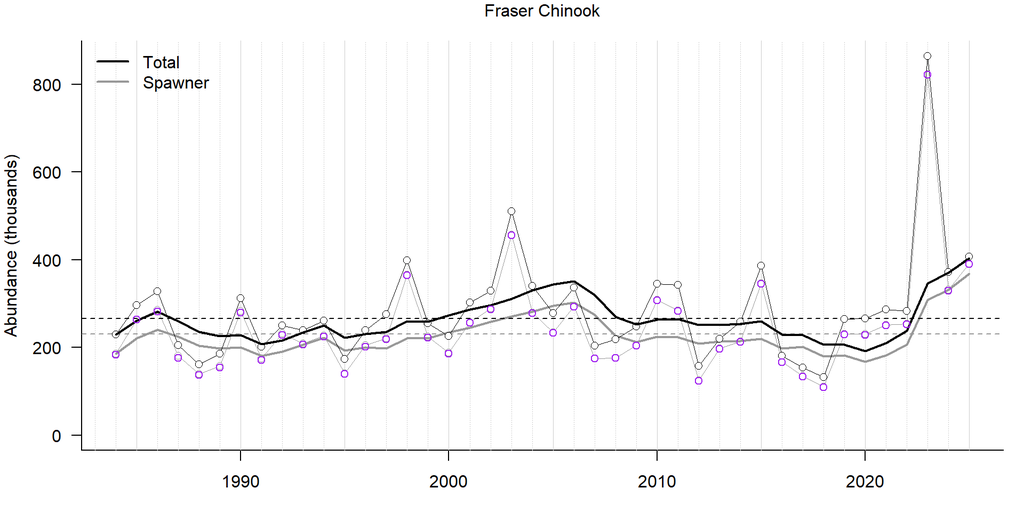

**Above:** Spawner abundance (grey) and total abundance (black) of Fraser chinook salmon. For both, the raw data is shown by points and the smoothed metric by solid lines. Dashed horizonal lines represent the long-term average for each.

[figure not shown]

**Above:** (a) Aggregate escapement of Fraser Chinook with the contribution of escapement to each of five stocks shown as coloured regions. Note that the Harrison River (Fall 4-1) time series begins later (1984) than the other four stocks (1975), and thus we only report spawner abundance from 1984 onward. (b) The proportional contribution of each of five stocks to aggregate Fraser Chinook escapement.

```r
frck_smu <- rep(stringr::str_remove_all(frck_smu, "Fraser|age|-run|[[:punct:]]|[[:space:]]")[!is.na(frck_smu)], each=2)
names(frck)[2:ncol(frck)] <- paste(frck_smu, stringr::str_extract_all(names(frck)[2:ncol(frck)], "Esc|Run"), sep="_") # stitch together smu and col names
names(frck) <- stringr::str_to_lower(names(frck))


# Cut data to only 1984 onward when Harrison data were available.
frck <- frck %>% dplyr::filter(year >= 1984)

# Sum across SMUs
frck_esc <- round(apply(frck[, grep("esc", names(frck))], 1, sum))
frck_run <- round(apply(frck[, grep("run", names(frck))], 1, sum))

yrs <- frck$year

# Put in SPS format
frck_sps <- data.frame(
    region = rep("Fraser", length(yrs)),
    species = rep("Chinook", length(yrs)),
    year = yrs,
    spawners = frck_esc,
    smoothedSpawners = NA,
    runsize = frck_run,
    smoothedRunsize = NA,
    source_id = rep("Weir_20260424", length(yrs))
)

    # Smoothing
frck_sps$smoothedSpawners <- genSmooth(
        abund = frck_sps$spawners,
        years = frck_sps$year,
        genLength = genLength$gen_length[genLength$region == "Fraser" & genLength$species == "Chinook"]
    )

frck_sps$smoothedRunsize <- genSmooth(
    abund = frck_sps$runsize,
    years = frck_sps$year,
    genLength = genLength$gen_length[genLength$region == "Fraser" & genLength$species == "Chinook"]
)


# Add to master sps dataframe
sps_data <- rbind(sps_data, frck_sps)

# Generate standard figure
plot_abund(frck_sps)

# Load CTC data for comparison
frck_ctc <- readxl::read_xlsx(here("data/TCCHINOOK-2026-Appendix-B-Escapement-Detailed.xlsx"), sheet = "B6", range = "A5:G54", col_types = "numeric", col_names = c("Year", "Spr12_esc", "Spr13_esc", "Sum03_esc", "Sum13_esc", "SprSum_trun", "Harr_esc"))
frck_ctc <- frck_ctc %>% mutate(total_esc = Spr12_esc + Spr13_esc + Sum03_esc + Sum13_esc + Harr_esc)

# Plot comparison
points(x=frck_ctc$Year, y=frck_ctc$total_esc/1000, col="purple")
```